# Analysis or House Prices

Jaehun

2022-08-09

### 참고자료

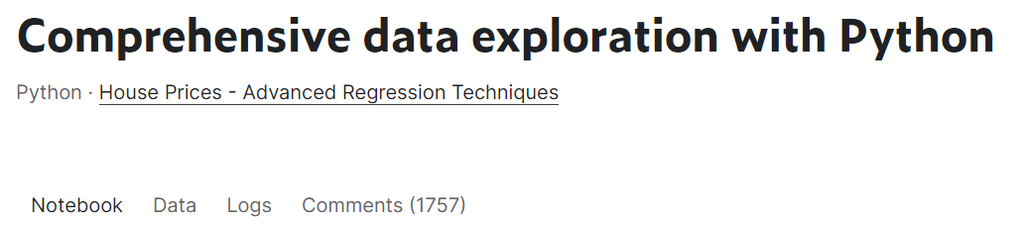

주소 : “https://www.kaggle.com/code/pmarcelino/comprehensive-data-exploration-with-python”  
Kaggle 사이트에서 House Price 와 관련된 코드 중 가장 ’좋아요’가 높은 페이지.

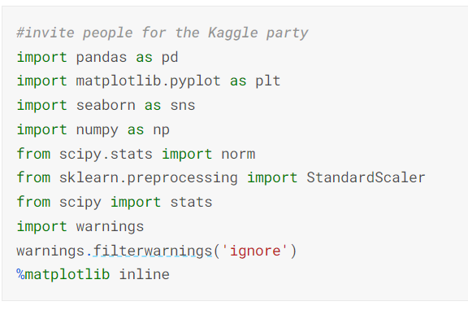

분석 특징  
- 파이썬으로 작성됨  
- 따라가기 쉬움 (자료랑 데이트하는 컨샙)

### 1. 데이터의 기본적인 정보 확인

```
##        Id           MSSubClass      MSZoning          LotFrontage
##  Min.   :   1.0   Min.   : 20.0   Length:1460        Min.   : 21.00
##  1st Qu.: 365.8   1st Qu.: 20.0   Class :character   1st Qu.: 59.00
##  Median : 730.5   Median : 50.0   Mode  :character   Median : 69.00
##  Mean   : 730.5   Mean   : 56.9                      Mean   : 70.05
##  3rd Qu.:1095.2   3rd Qu.: 70.0                      3rd Qu.: 80.00
##  Max.   :1460.0   Max.   :190.0                      Max.   :313.00
##                                                      NA's   :259
##     LotArea          Street             Alley             LotShape
##  Min.   :  1300   Length:1460        Length:1460        Length:1460
##  1st Qu.:  7554   Class :character   Class :character   Class :character
##  Median :  9478   Mode  :character   Mode  :character   Mode  :character
##  Mean   : 10517
##  3rd Qu.: 11602
##  Max.   :215245
##
##  LandContour         Utilities          LotConfig          LandSlope
##  Length:1460        Length:1460        Length:1460        Length:1460
##  Class :character   Class :character   Class :character   Class :character
##  Mode  :character   Mode  :character   Mode  :character   Mode  :character
##
##
##
##
##  Neighborhood        Condition1         Condition2          BldgType
##  Length:1460        Length:1460        Length:1460        Length:1460
##  Class :character   Class :character   Class :character   Class :character
##  Mode  :character   Mode  :character   Mode  :character   Mode  :character
##
##
##
##
##   HouseStyle         OverallQual      OverallCond      YearBuilt
##  Length:1460        Min.   : 1.000   Min.   :1.000   Min.   :1872
##  Class :character   1st Qu.: 5.000   1st Qu.:5.000   1st Qu.:1954
##  Mode  :character   Median : 6.000   Median :5.000   Median :1973
##                     Mean   : 6.099   Mean   :5.575   Mean   :1971
##                     3rd Qu.: 7.000   3rd Qu.:6.000   3rd Qu.:2000
##                     Max.   :10.000   Max.   :9.000   Max.   :2010
##
```

[output cut: 113 more lines]

```
##  Min.   : 1.000   Min.   :2006   Length:1460        Length:1460
##  1st Qu.: 5.000   1st Qu.:2007   Class :character   Class :character
##  Median : 6.000   Median :2008   Mode  :character   Mode  :character
##  Mean   : 6.322   Mean   :2008
##  3rd Qu.: 8.000   3rd Qu.:2009
##  Max.   :12.000   Max.   :2010
##
##    SalePrice
##  Min.   : 34900
##  1st Qu.:129975
##  Median :163000
##  Mean   :180921
##  3rd Qu.:214000
##  Max.   :755000
##
```

```
## [1] 1460   81
```

**81**개의 컬럼이라 변수들 중에서 유의미하다고 생각하는 변수를 뽑아서 사용할 필요가 있다.

### 2. 기준 변수 분석

#### 2.1 SalePrice 분석

```
##    Min. 1st Qu.  Median    Mean 3rd Qu.    Max.
##   34900  129975  163000  180921  214000  755000
```

#### 2.2 SalePrice 도수분포표

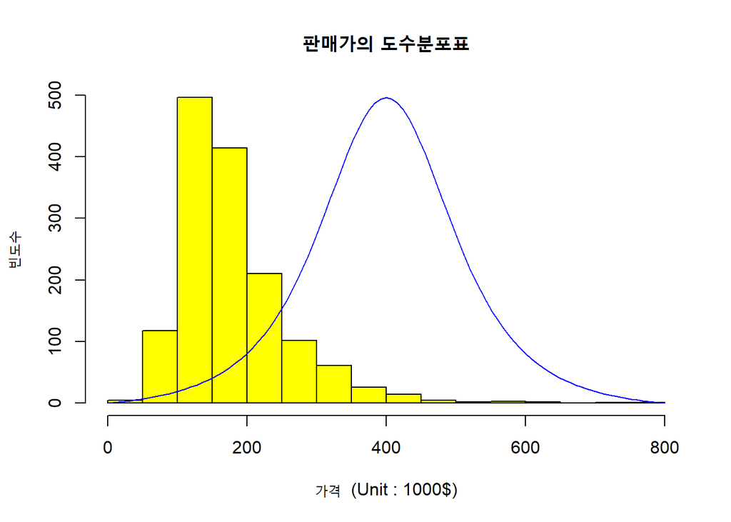

#### 2.3 SalePrice 이상치 확인

```
##  int [1:1460] 208500 181500 223500 140000 250000 143000 307000 200000 129900 118000 ...
```

```
## 이상치 수 : 61
```

```
## 왜도 :  1.880941
```

```
## 첨도 :  9.509812
```

정규분포의 왜도 첨도 기준을 벗어난 푸아성 분포로 부동산 예측을 위한 좋은 모델이라고 할 수는 없다.(????)

### 푸아성분포

#### 일정 주어진 생산시간 동안 발생하는 불량 수와 처럼

#### 특정 사건의 발생 확률이 아주 작은 확률분포로

#### 정규분포처럼 예측을 위한 보편성을 가진 분포는 아니다(????).

#### 2.4 기본정보를 시각화

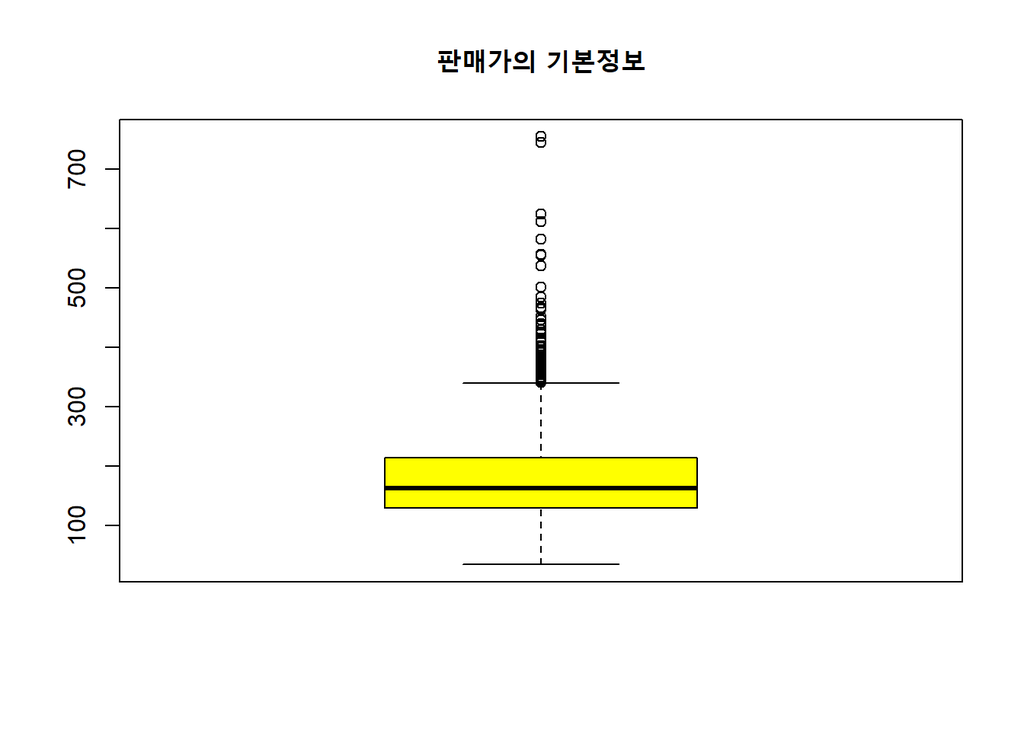

**자료의 특징**  
1. 한쪽으로 치우쳐져 있다(왜도가 크다)  
2. 특정값에 몰려있다.(첨도가 높다)

### 3. 변수 설정

#### 3.1 수치형 변수 선정

```
##  [1] "Id"            "MSSubClass"    "MSZoning"      "LotFrontage"
##  [5] "LotArea"       "Street"        "Alley"         "LotShape"
##  [9] "LandContour"   "Utilities"     "LotConfig"     "LandSlope"
## [13] "Neighborhood"  "Condition1"    "Condition2"    "BldgType"
## [17] "HouseStyle"    "OverallQual"   "OverallCond"   "YearBuilt"
## [21] "YearRemodAdd"  "RoofStyle"     "RoofMatl"      "Exterior1st"
## [25] "Exterior2nd"   "MasVnrType"    "MasVnrArea"    "ExterQual"
## [29] "ExterCond"     "Foundation"    "BsmtQual"      "BsmtCond"
## [33] "BsmtExposure"  "BsmtFinType1"  "BsmtFinSF1"    "BsmtFinType2"
## [37] "BsmtFinSF2"    "BsmtUnfSF"     "TotalBsmtSF"   "Heating"
## [41] "HeatingQC"     "CentralAir"    "Electrical"    "X1stFlrSF"
## [45] "X2ndFlrSF"     "LowQualFinSF"  "GrLivArea"     "BsmtFullBath"
## [49] "BsmtHalfBath"  "FullBath"      "HalfBath"      "BedroomAbvGr"
## [53] "KitchenAbvGr"  "KitchenQual"   "TotRmsAbvGrd"  "Functional"
## [57] "Fireplaces"    "FireplaceQu"   "GarageType"    "GarageYrBlt"
## [61] "GarageFinish"  "GarageCars"    "GarageArea"    "GarageQual"
## [65] "GarageCond"    "PavedDrive"    "WoodDeckSF"    "OpenPorchSF"
## [69] "EnclosedPorch" "X3SsnPorch"    "ScreenPorch"   "PoolArea"
## [73] "PoolQC"        "Fence"         "MiscFeature"   "MiscVal"
## [77] "MoSold"        "YrSold"        "SaleType"      "SaleCondition"
## [81] "SalePrice"
```

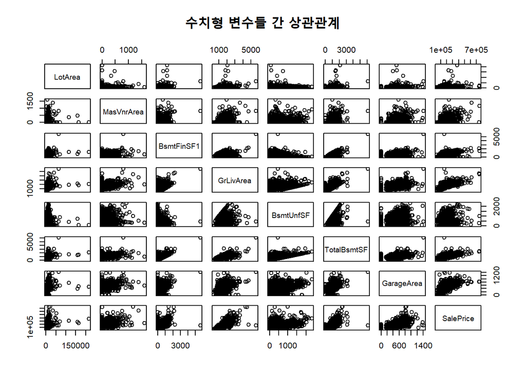

#### 3.2 GrLivArea(거실 면적 평방피트 0.03평) 변수와 가격 간의 상관관계

#### 3.2.1 거실 면적 도수분포표

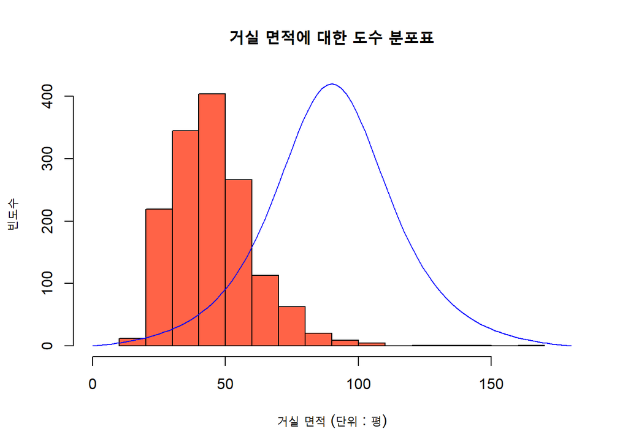

#### 3.2.2 거실 면적의 기본정보

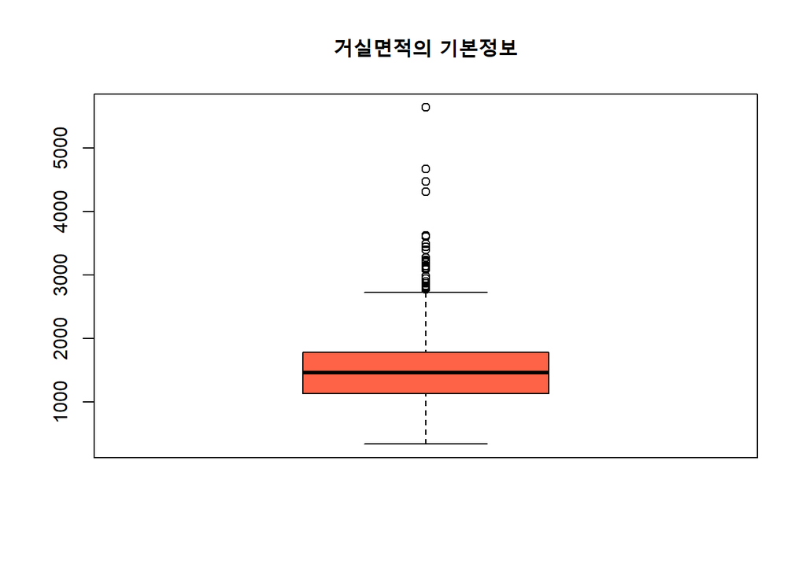

#### 3.2.3 가격과 거실 면적 간 산점도

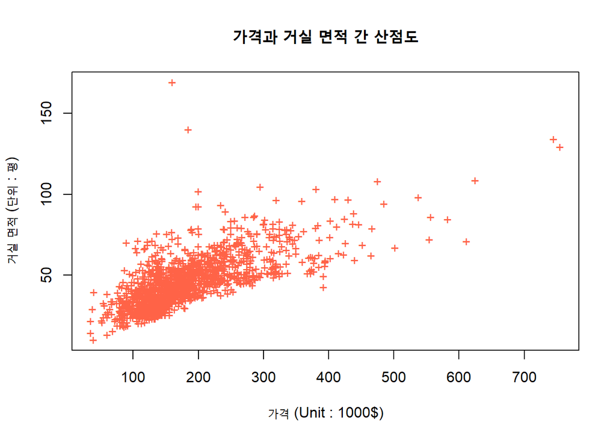

#### 3.3 질적변수

#### 3.3.1 OverallQual(전체 상태 등급) 변수 분석

```
##
##   1   2   3   4   5   6   7   8   9  10
##   2   3  20 116 397 374 319 168  43  18
```

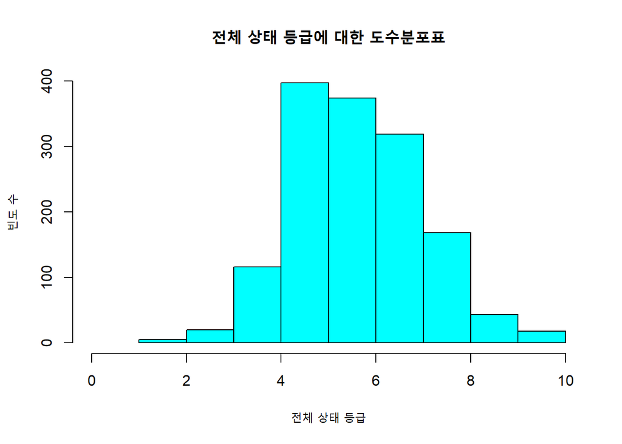

#### 3.3.2 가격과 전체 상태 등급 간의 상관관계

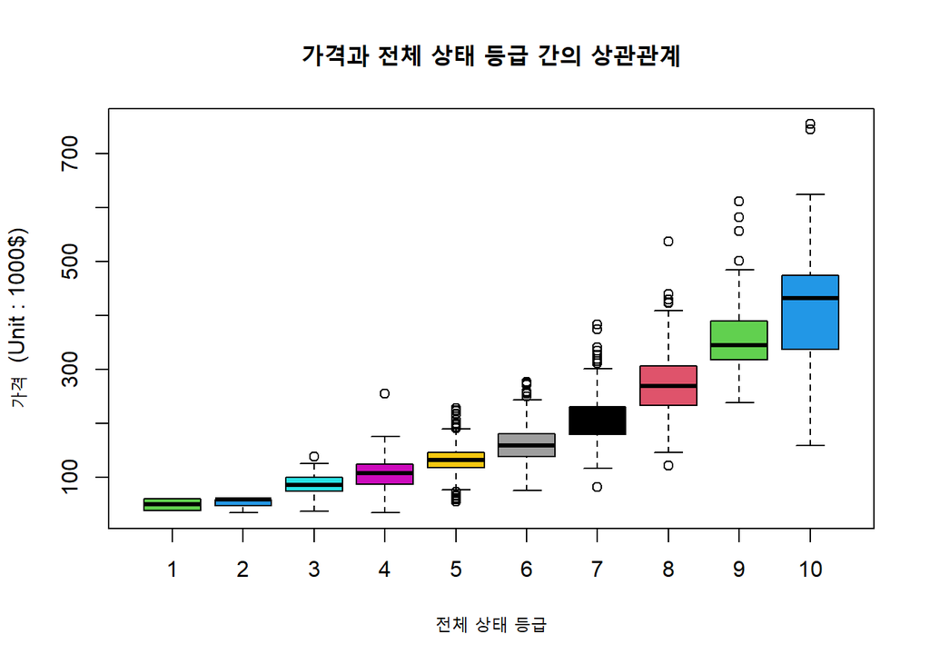

#### 4. 이상치를 제거하고 비교

#### 4.1 자료에서 이상치 확인 후 제거

```
## [1]  34900 129950 163000 214000 340000
```

```
## [1]  334.0 1129.0 1464.0 1777.5 2730.0
```

#### 가격과 면적의 이상치 정도

```
## 가격에서 이상치 비중 : 0.04
```

```
## 면적에서 이상치 비중 : 0.02
```

#### 4.2 이상치 유무에 따른 도수분포표 비교

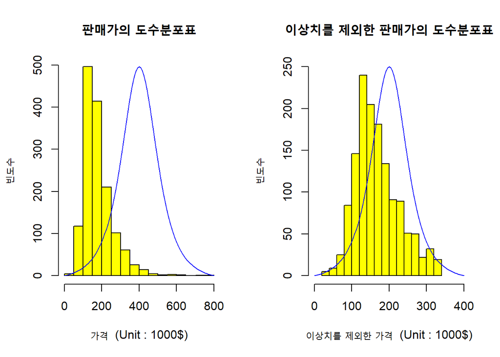

#### 4.2 이상치 유무에 따른 가격과 면적 간의 산점도 비교

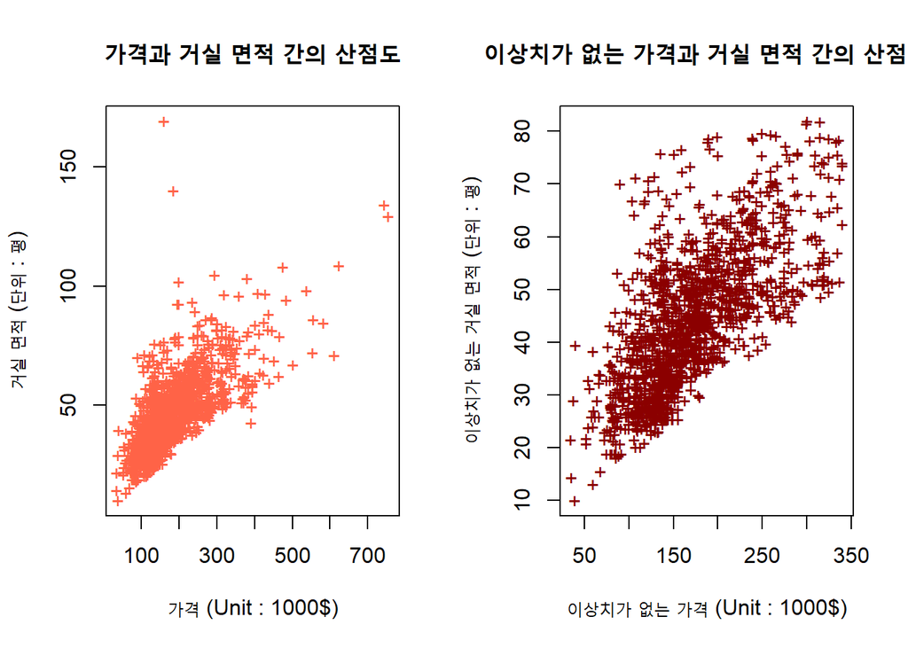

#### 4.3 이상치 유무에 따른 가격과 등급 간의 상관관계 비교

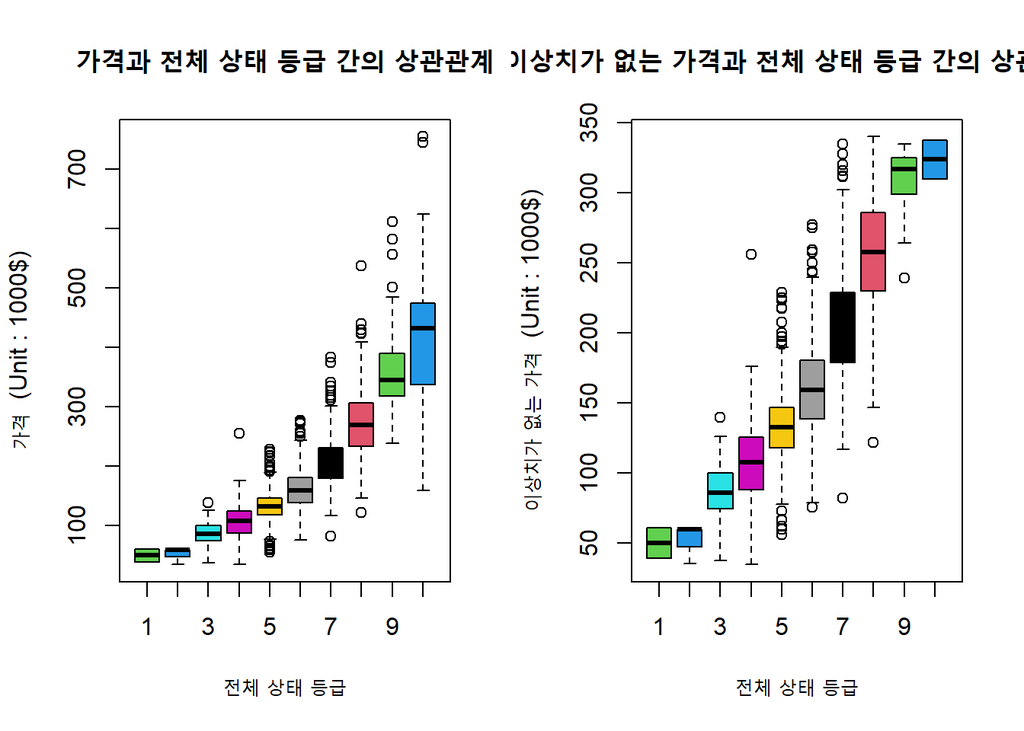

#### 5 첨도와 왜도, 상관계수

```
##                    모든.데이터 이상치.제거.데이터
## 가격 왜도                 1.88               0.69
## 가격 첨도                 9.51               3.14
## 면적 왜도                 1.37               0.46
## 면적 첨도                 7.87               2.84
## 가격-면적 상관계수        0.71               0.69
## 가격-등급 상관계수        0.79               0.79
```

#### 6. 결론

최종결론???  
**데이터 셋**  
우리가 알고 있는 일반적인 지식이 가격을 예측하는데 유효하다.